# Project: Investigate a TMDb Movie Dataset

The project aim to go through a basic process of data analysis with some python libraries including pandas, numpy, matplotlib to provide some interesting insight from the given dataset.

The process include 4 main stages:

- Introduction
- Data Wrangling
- Exploratory Data Analysis
- Conclusions

## Introduction

This data set contains information about 10,000 movies collected from The Movie Database (TMDb), including user ratings and revenue

Dataset characteristic:

> - 10866 rows and 21 columns
> - Contain some null values and bias informations
> - Rich in aspects available for observation, from financial to audience's taste to production information

The analysis should answer the following main questions:

> 1. What are the top movies with highest/lowest revenue/budget/popularity/profit of all time?
> 2. What is the movie industry's profit overtime in total and across genres?
> 3. What time of the year should the movie be realsed to optimize profit?

```python
#Import libraries
import pandas as pd
import numpy as np
import seaborn as sns
import matplotlib.pyplot as plt

%matplotlib inline
```

## Data Wrangling

### General Properties

```python
# Load the data
df_movie = pd.read_csv('tmdb-movies.csv')
```

```python
df_movie.describe()
```

|  | id | popularity | budget | revenue | runtime | vote_count | vote_average | release_year | budget_adj | revenue_adj |
| --- | --- | --- | --- | --- | --- | --- | --- | --- | --- | --- |
| count | 10866.000000 | 10866.000000 | 1.086600e+04 | 1.086600e+04 | 10866.000000 | 10866.000000 | 10866.000000 | 10866.000000 | 1.086600e+04 | 1.086600e+04 |
| mean | 66064.177434 | 0.646441 | 1.462570e+07 | 3.982332e+07 | 102.070863 | 217.389748 | 5.974922 | 2001.322658 | 1.755104e+07 | 5.136436e+07 |
| std | 92130.136561 | 1.000185 | 3.091321e+07 | 1.170035e+08 | 31.381405 | 575.619058 | 0.935142 | 12.812941 | 3.430616e+07 | 1.446325e+08 |
| min | 5.000000 | 0.000065 | 0.000000e+00 | 0.000000e+00 | 0.000000 | 10.000000 | 1.500000 | 1960.000000 | 0.000000e+00 | 0.000000e+00 |
| 25% | 10596.250000 | 0.207583 | 0.000000e+00 | 0.000000e+00 | 90.000000 | 17.000000 | 5.400000 | 1995.000000 | 0.000000e+00 | 0.000000e+00 |
| 50% | 20669.000000 | 0.383856 | 0.000000e+00 | 0.000000e+00 | 99.000000 | 38.000000 | 6.000000 | 2006.000000 | 0.000000e+00 | 0.000000e+00 |
| 75% | 75610.000000 | 0.713817 | 1.500000e+07 | 2.400000e+07 | 111.000000 | 145.750000 | 6.600000 | 2011.000000 | 2.085325e+07 | 3.369710e+07 |
| max | 417859.000000 | 32.985763 | 4.250000e+08 | 2.781506e+09 | 900.000000 | 9767.000000 | 9.200000 | 2015.000000 | 4.250000e+08 | 2.827124e+09 |

The dataset have 10866 rows and 21 columns

```python
# Number of rows and columns
df_movie.shape
```

```
(10866, 21)
```

```python
# Names of colummns
print(list(df_movie.columns))
```

```
['id', 'imdb_id', 'popularity', 'budget', 'revenue', 'original_title', 'cast', 'homepage', 'director', 'tagline', 'keywords', 'overview', 'runtime', 'genres', 'production_companies', 'release_date', 'vote_count', 'vote_average', 'release_year', 'budget_adj', 'revenue_adj']
```

```python
#Information about datatype and which columns contain nullvalues
df_movie.info()
```

```
<class 'pandas.core.frame.DataFrame'>
RangeIndex: 10866 entries, 0 to 10865
Data columns (total 21 columns):
 #   Column                Non-Null Count  Dtype
---  ------                --------------  -----
 0   id                    10866 non-null  int64
 1   imdb_id               10856 non-null  object
 2   popularity            10866 non-null  float64
 3   budget                10866 non-null  int64
 4   revenue               10866 non-null  int64
 5   original_title        10866 non-null  object
 6   cast                  10790 non-null  object
 7   homepage              2936 non-null   object
 8   director              10822 non-null  object
 9   tagline               8042 non-null   object
 10  keywords              9373 non-null   object
 11  overview              10862 non-null  object
 12  runtime               10866 non-null  int64
 13  genres                10843 non-null  object
 14  production_companies  9836 non-null   object
 15  release_date          10866 non-null  object
 16  vote_count            10866 non-null  int64
 17  vote_average          10866 non-null  float64
 18  release_year          10866 non-null  int64
 19  budget_adj            10866 non-null  float64
 20  revenue_adj           10866 non-null  float64
dtypes: float64(4), int64(6), object(11)
memory usage: 1.7+ MB
```

### Dataset's statistical overviews

It can be seen that some rows have the value of budget or revenue or runtime equal to 0, which likely to be false information

```python
df_movie.describe()
```

|  | id | popularity | budget | revenue | runtime | vote_count | vote_average | release_year | budget_adj | revenue_adj |
| --- | --- | --- | --- | --- | --- | --- | --- | --- | --- | --- |
| count | 10866.000000 | 10866.000000 | 1.086600e+04 | 1.086600e+04 | 10866.000000 | 10866.000000 | 10866.000000 | 10866.000000 | 1.086600e+04 | 1.086600e+04 |
| mean | 66064.177434 | 0.646441 | 1.462570e+07 | 3.982332e+07 | 102.070863 | 217.389748 | 5.974922 | 2001.322658 | 1.755104e+07 | 5.136436e+07 |
| std | 92130.136561 | 1.000185 | 3.091321e+07 | 1.170035e+08 | 31.381405 | 575.619058 | 0.935142 | 12.812941 | 3.430616e+07 | 1.446325e+08 |
| min | 5.000000 | 0.000065 | 0.000000e+00 | 0.000000e+00 | 0.000000 | 10.000000 | 1.500000 | 1960.000000 | 0.000000e+00 | 0.000000e+00 |
| 25% | 10596.250000 | 0.207583 | 0.000000e+00 | 0.000000e+00 | 90.000000 | 17.000000 | 5.400000 | 1995.000000 | 0.000000e+00 | 0.000000e+00 |
| 50% | 20669.000000 | 0.383856 | 0.000000e+00 | 0.000000e+00 | 99.000000 | 38.000000 | 6.000000 | 2006.000000 | 0.000000e+00 | 0.000000e+00 |
| 75% | 75610.000000 | 0.713817 | 1.500000e+07 | 2.400000e+07 | 111.000000 | 145.750000 | 6.600000 | 2011.000000 | 2.085325e+07 | 3.369710e+07 |
| max | 417859.000000 | 32.985763 | 4.250000e+08 | 2.781506e+09 | 900.000000 | 9767.000000 | 9.200000 | 2015.000000 | 4.250000e+08 | 2.827124e+09 |

### Inspecting the dataset

The dataset have some columns that refers to the identity of the movie and extra information about the content such as imdb_id, homepage,... Some other columns provide information about the actors, director or the movies properties. And there are also columns relate to the movie's financial values.

```python
pd.set_option('display.max_columns', 30)
# A sample of the dataset
df_movie.head()
```

|  | id | imdb_id | popularity | budget | revenue | original_title | cast | homepage | director | tagline | keywords | overview | runtime | genres | production_companies | release_date | vote_count | vote_average | release_year | budget_adj | revenue_adj |
| --- | --- | --- | --- | --- | --- | --- | --- | --- | --- | --- | --- | --- | --- | --- | --- | --- | --- | --- | --- | --- | --- |
| 0 | 135397 | tt0369610 | 32.985763 | 150000000 | 1513528810 | Jurassic World | Chris Pratt\|Bryce Dallas Howard\|Irrfan Khan\|Vi... | http://www.jurassicworld.com/ | Colin Trevorrow | The park is open. | monster\|dna\|tyrannosaurus rex\|velociraptor\|island | Twenty-two years after the events of Jurassic ... | 124 | Action\|Adventure\|Science Fiction\|Thriller | Universal Studios\|Amblin Entertainment\|Legenda... | 6/9/15 | 5562 | 6.5 | 2015 | 1.379999e+08 | 1.392446e+09 |
| 1 | 76341 | tt1392190 | 28.419936 | 150000000 | 378436354 | Mad Max: Fury Road | Tom Hardy\|Charlize Theron\|Hugh Keays-Byrne\|Nic... | http://www.madmaxmovie.com/ | George Miller | What a Lovely Day. | future\|chase\|post-apocalyptic\|dystopia\|australia | An apocalyptic story set in the furthest reach... | 120 | Action\|Adventure\|Science Fiction\|Thriller | Village Roadshow Pictures\|Kennedy Miller Produ... | 5/13/15 | 6185 | 7.1 | 2015 | 1.379999e+08 | 3.481613e+08 |
| 2 | 262500 | tt2908446 | 13.112507 | 110000000 | 295238201 | Insurgent | Shailene Woodley\|Theo James\|Kate Winslet\|Ansel... | http://www.thedivergentseries.movie/#insurgent | Robert Schwentke | One Choice Can Destroy You | based on novel\|revolution\|dystopia\|sequel\|dyst... | Beatrice Prior must confront her inner demons ... | 119 | Adventure\|Science Fiction\|Thriller | Summit Entertainment\|Mandeville Films\|Red Wago... | 3/18/15 | 2480 | 6.3 | 2015 | 1.012000e+08 | 2.716190e+08 |
| 3 | 140607 | tt2488496 | 11.173104 | 200000000 | 2068178225 | Star Wars: The Force Awakens | Harrison Ford\|Mark Hamill\|Carrie Fisher\|Adam D... | http://www.starwars.com/films/star-wars-episod... | J.J. Abrams | Every generation has a story. | android\|spaceship\|jedi\|space opera\|3d | Thirty years after defeating the Galactic Empi... | 136 | Action\|Adventure\|Science Fiction\|Fantasy | Lucasfilm\|Truenorth Productions\|Bad Robot | 12/15/15 | 5292 | 7.5 | 2015 | 1.839999e+08 | 1.902723e+09 |
| 4 | 168259 | tt2820852 | 9.335014 | 190000000 | 1506249360 | Furious 7 | Vin Diesel\|Paul Walker\|Jason Statham\|Michelle ... | http://www.furious7.com/ | James Wan | Vengeance Hits Home | car race\|speed\|revenge\|suspense\|car | Deckard Shaw seeks revenge against Dominic Tor... | 137 | Action\|Crime\|Thriller | Universal Pictures\|Original Film\|Media Rights ... | 4/1/15 | 2947 | 7.3 | 2015 | 1.747999e+08 | 1.385749e+09 |

Most of the movies are low in budget and revenue.

and The movies are released more and more every year

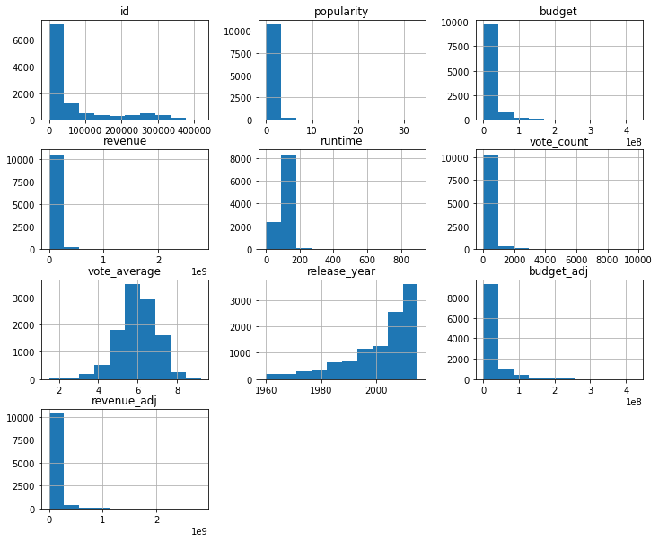

```python
df_movie.hist(figsize=(12,10));
```

### Data Cleaning

Looking at the sample, there are some columns that provide unnecessary information for analysis such as imdb_id, homepage, tagline... (these column provide extra information about the movie content or a substitute identity for the movie, but the only things we need when refer to the movie should be its offical name)

Also, since budget_adj and revenue_adj would be more appropriate to measure, budget and revenue will be removed

As the analysis will be focus more into the movies, information about actor and production will be eliminated

So i will remove the above columns in the dataset

```python
df_movie.drop(['id','imdb_id','homepage','tagline','overview','production_companies','director','cast','budget','revenue'], axis=1, inplace=True)
```

#### Check and remove duplicated values

```python
df_movie[df_movie.duplicated() == True].shape
```

```
(1, 11)
```

```python
df_movie.drop_duplicates(inplace=True)
```

```python
#check if the rows have been removed
df_movie[df_movie.duplicated() == True].shape
```

```
(0, 11)
```

#### Removes rows with the value of budget or revenue or runtime equal to 0

```python
df_movie.query("(budget_adj == 0) | (revenue_adj == 0) | (runtime == 0)" ).shape
```

```
(7011, 11)
```

```python
df_movie = df_movie[df_movie['budget_adj'] > 0]
df_movie = df_movie[df_movie['revenue_adj'] > 0]
df_movie = df_movie[df_movie['runtime'] > 0]
```

```python
#check if the rows have been removed
df_movie.query("(budget_adj == 0) | (revenue_adj == 0) | (runtime == 0)" ).shape
```

```
(0, 11)
```

#### Convert date column to the appropriate format

```python
df_movie['release_date'] = pd.to_datetime(df_movie['release_date'])
```

## Exploratory Data Analysis

The analysis will first explore some basic feature of the data set such as the information about some stand out movies using single-variable. Then it will answer the questions with multi-variable observation.

This analysis will focus mostly on the financial aspects of the dataset, to find out what movie and what genre of movie that is most profitable.

### Research Question 1: What are the top movies with highest/lowest revenue/budget/popularity/profit of all time?

```python
#create a profit column
df_movie['profit'] = df_movie['revenue_adj'] - df_movie['budget_adj']
```

```python
#create a function to show a bar chart of top movies by sort attribute
def plot_top10_movies(df, x_column, sort_attribute):
    # sort the dataframe by x_column and select the top 10 rows by attribute
    if  sort_attribute == 'highest':
        df_sorted = df.sort_values(x_column, ascending=False).head(10)
    elif sort_attribute == 'lowest':
        df_sorted = df.sort_values(x_column, ascending=True).head(10)

    # define the dictionary that maps the column name to the correct name for axis
    column_dic = {"popularity": 'Popularity', "budget_adj": 'Budget (in USD)',
                  "revenue_adj": 'Revenue (in USD)', "profit": 'Profit (in USD)'}
    axis_name=column_dic.get(x_column)

    # create a bar chart
    sns.set_style("whitegrid")
    plt.figure(figsize=(12, 5))
    ax = sns.barplot(x="original_title", y=x_column, data=df_sorted, palette="husl")


    # Set the x-axis label and title
    ax.set_xlabel('Movie Name',fontsize = 13)
    ax.set_title(f'Top 10 Movies with {sort_attribute} {axis_name}',fontsize = 15)

    # Set the y-axis label and format
    ax.set_ylabel(f'{axis_name}',fontsize = 13)
    ax.yaxis.set_major_formatter('${x:,.0f}')

    # display the chart
    plt.xticks(rotation=90)
    plt.show()
```

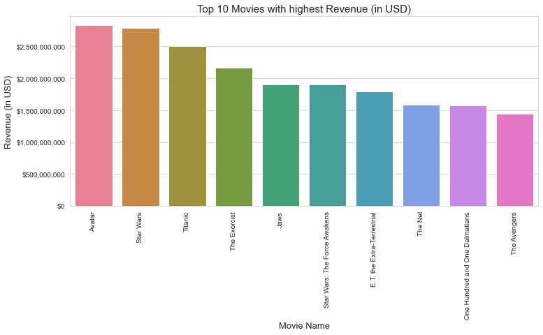

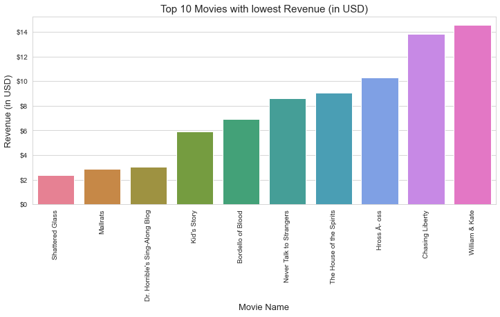

```python
#Top 10 movies by revenue
plot_top10_movies(df_movie,'revenue_adj','highest')
plot_top10_movies(df_movie,'revenue_adj','lowest')
```

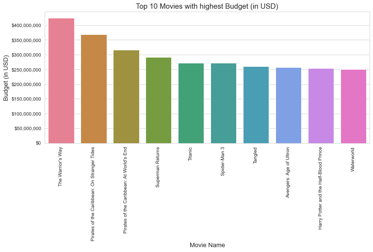

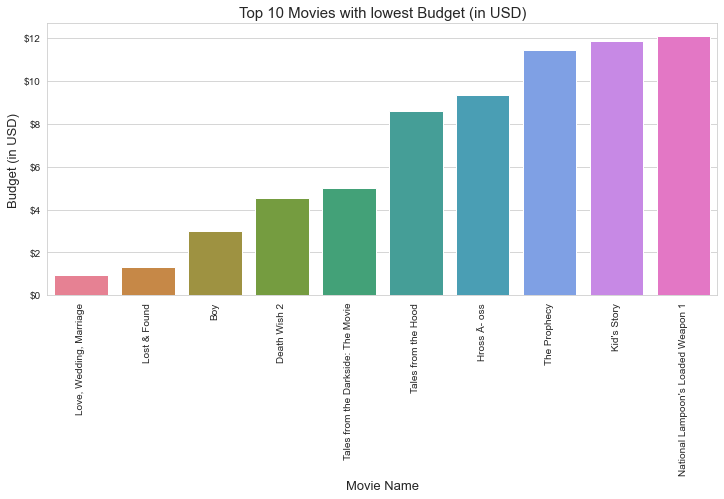

```python
#Top 10 movies by budget
plot_top10_movies(df_movie,'budget_adj','highest')
plot_top10_movies(df_movie,'budget_adj','lowest')
```

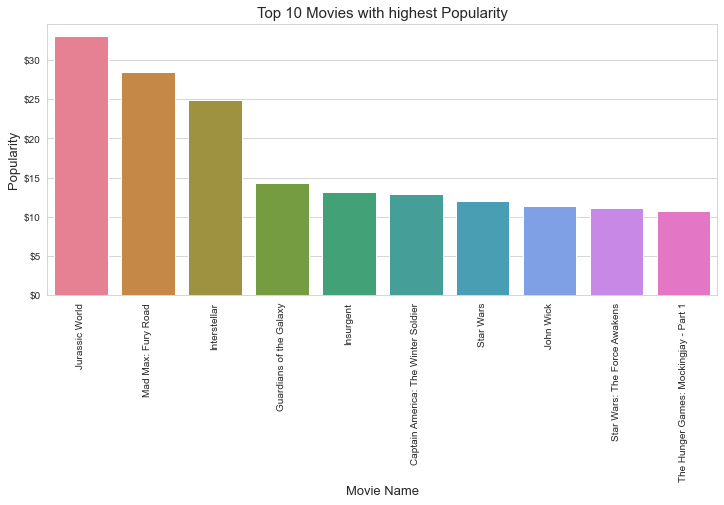

[figure not shown]

```python
#Top 10 movies by popularity
plot_top10_movies(df_movie,'popularity','highest')
plot_top10_movies(df_movie,'popularity','lowest')
```

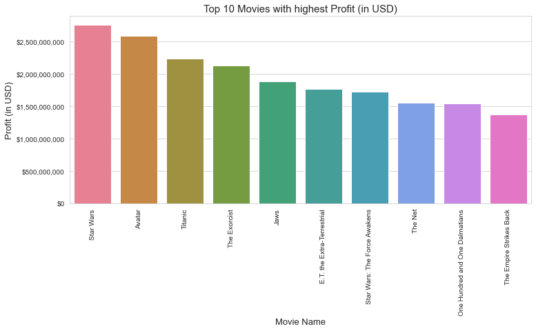

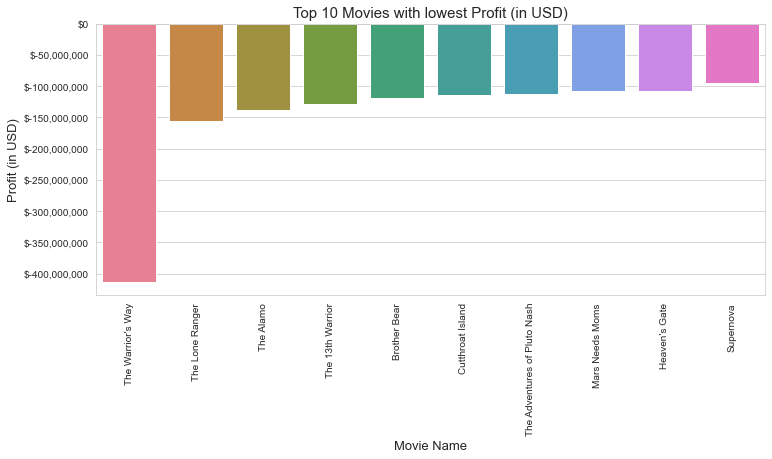

```python
#Top 10 movies by profit
plot_top10_movies(df_movie,'profit','highest')
plot_top10_movies(df_movie,'profit','lowest')
```

### Research Question 2: What is the movie industry's profit overtime in total and across genres?

This should help us find out what is the genres that give the most profit

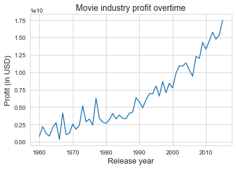

```python
df_movie.groupby('release_year')['profit'].sum().plot()

#setup the title and labels of the figure.
plt.title('Movie industry profit overtime',fontsize = 14)
plt.xlabel('Release year',fontsize = 13)
plt.ylabel('Profit (in USD)',fontsize = 13)

#setup the figure size.
sns.set(rc={'figure.figsize':(13,8)})
sns.set_style("whitegrid")
```

> Overall, The movie industry is on a rising trend over the years, this might have a strong correlation with the economy as the profit decline over in the periods associate with global recessions

#### The movie industry's profit accross genres

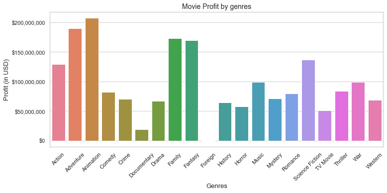

```python
# Get list of genres
genre_list = df_movie['genres'].str.split('|', expand=True)
genre_list = genre_list.apply(pd.Series.value_counts).index.tolist()
genre_list = np.array(genre_list)

#create a dataframe to stores the profit of each genres
df_genre = pd.DataFrame(columns=['genre','profit'])

# Add the NumPy array as a new column in the DataFrame
df_genre['genre'] = genre_list

#Find the profit of each genre:
for i in genre_list:
    df = df_movie[df_movie['genres'].str.contains(i)]

    # Calculate the total profit for the filtered DataFrame
    df_genre.loc[df_genre['genre'] == i, 'profit'] = df['profit'].mean()


# create a bar chart
sns.set_style("whitegrid")
plt.figure(figsize=(12, 5))
ax = sns.barplot(x="genre", y="profit", data=df_genre, palette="husl")


# Set the x-axis label and title
ax.set_xlabel('Genres',fontsize = 13)
ax.set_title('Movie Profit by genres',fontsize = 14)

# Set the y-axis label and format
ax.set_ylabel('Profit (in USD)',fontsize = 13)
ax.yaxis.set_major_formatter('${x:,.0f}')

# display the chart
plt.xticks(rotation=45)
plt.show()
```

> It seems like movies in the genres of animation are more likely to make the the most profit. While movies in the Foreign genre bring a negative value

```python
#check Foreign genre average profit
print(df_genre[df_genre['genre'] == 'Foreign'])
```

```
     genre         profit
9  Foreign -164463.929119
```

#### Watching the profit trend of each genre over year

I wanted to see how the profit of each genres vary over the year and see if it would be true that making animation movie is less risky now than in the past

In order to do this, it would require me to get the profit of each trend every year and it would be a little more complicated.

```python
# Get list of years and sort from oldest to newest
year_list = df['release_year'].value_counts().index.tolist()
year_list.sort()
year_list = np.array(year_list)

# Create the dataframe with a 'Year' column and genres as column
df_genre_yearly = pd.DataFrame(columns=genre_list)
df_genre_yearly.insert(0, 'Year',value=None)

# Add the NumPy array as a new column in the DataFrame
df_genre_yearly['Year'] = year_list
df_genre_yearly.head()

# Fill in the profit of each years across genres
for i in genre_list:
    for x in year_list:
    #find the profit of the genre 'i' in year 'x'
        df = df_movie[(df_movie['genres'].str.contains(i)) & (df_movie['release_year'] == x)]

    #replace the value of the cell in Dataframe
        df_genre_yearly.loc[df_genre_yearly['Year'] == x, i] = df['profit'].mean()
```

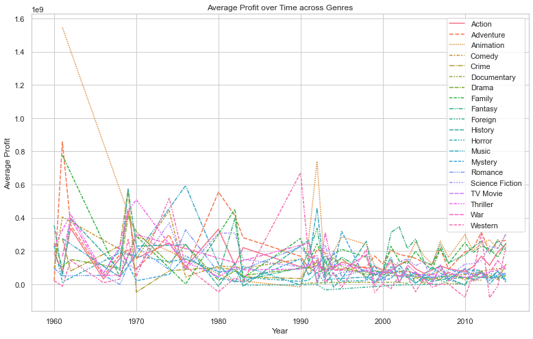

```python
df_genre_yearly = df_genre_yearly.set_index('Year')

# Plot multiple lines on the same graph
sns.set_style('whitegrid')
sns.lineplot(data=df_genre_yearly)

plt.title('Average Profit over Time across Genres')
plt.xlabel('Year')
plt.ylabel('Average Profit')
# Show the graph
plt.show()
```

> It seems like there is no genre that dominates the average profit alltime, they all experience up and down periods. However, we can assump that the trend is being more and more accurate in the recent times since that the amount of movies produced increase every years, providing more data and make the prediction more accurate.

> The animation genre's average profit had a increrible value in 1960s and a spike in 1990s and was among the tops in recent year, this explained why it has the highest average profit of alltime.

> Other than animation, some other genres that is stable and have a relative high average profit, espeacially in recent times are adventure, action and fantasy. This can be explained by the assumption that these genres are suitable for audience of all age and guarantee a certain sales. So most of them should have relative stable profit, and if there are loss occured, it wont be large (1)

##### Test assumption (1)

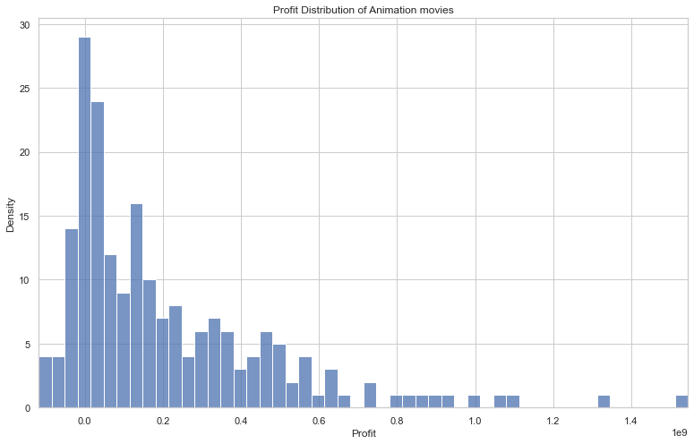

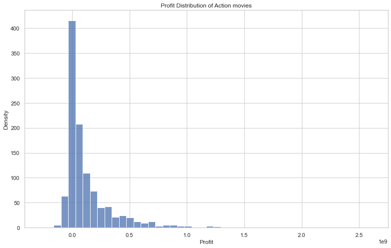

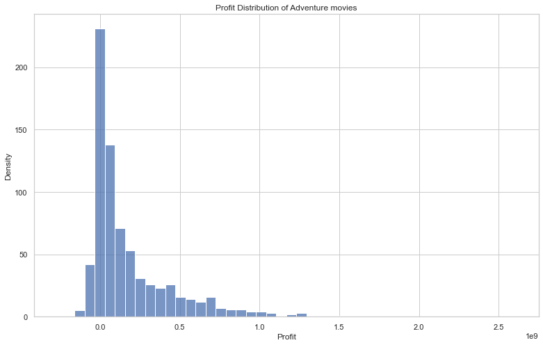

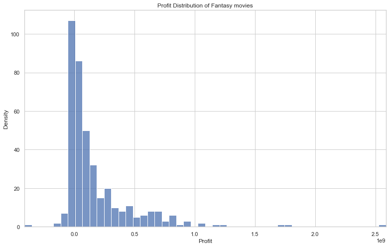

```python
  for x in ['Animation','Action','Adventure','Fantasy']:
    # Filter the dataset with x genres
    df = df_movie[df_movie['genres'].str.contains(x)]
    # Create the plot
    sns.histplot(df['profit'], bins=50)

    # Set the plot title and axes labels
    plt.title(f'Profit Distribution of {x} movies')
    plt.xlabel('Profit')
    plt.ylabel('Density')

    # Set the x-axis limits to include negative values
    plt.xlim(df['profit'].min(), df['profit'].max())

    # Show the plot
    plt.show()
```

> It can be seen that the 4 genres's profit are quite stable, and if there are losses occured, it wont be too large. Thus making these genre of movie quite safe to produce in term of profit.

##### Test assumption (2)

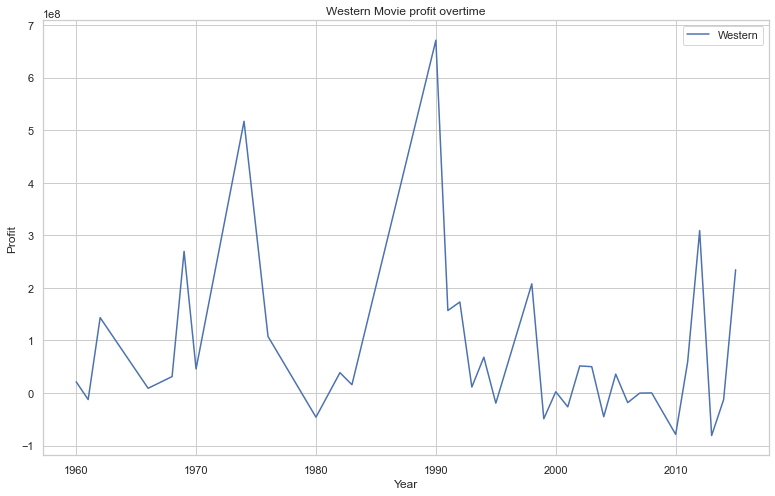

```python
#Looking closer to the Western genre
df_genre_yearly.plot(y='Western',kind='line')

# Set the plot title and axes labels
plt.title('Western Movie profit overtime')
plt.xlabel('Year')
plt.ylabel('Profit')

# Show the plot
plt.show()
```

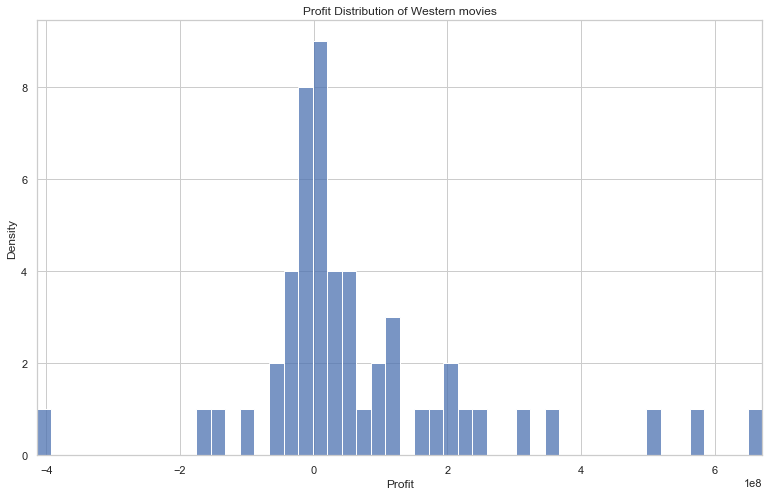

```python
# Filter the dataset with Western genres
df = df_movie[df_movie['genres'].str.contains('Western')]

# Create a histogram of the 'Profit' column using Seaborn
sns.histplot(df['profit'],bins=50)

# Set the plot title and axes labels
plt.title('Profit Distribution of Western movies')
plt.xlabel('Profit')
plt.ylabel('Density')

# Set the x-axis limits to include negative values
plt.xlim(df['profit'].min(), df['profit'].max())

# Show the plot
plt.show()
```

> As we can see from the histogram, the amount of Western movie that bring a little to negative profit is significant, some even bring huge loss and there also exist a number of Western movie with huge profit accross diagram, thus making the average profit of this genre spike in the year that these blockbusters are released

### Research Question 3: What time of the year should the movie be realsed to optimize profit?

```python
# Create a released month column
df_movie['month_released'] = df_movie['release_date'].dt.month
```

```python
df_movie.head()
```

|  | popularity | original_title | keywords | runtime | genres | release_date | vote_count | vote_average | release_year | budget_adj | revenue_adj | profit | month_released |
| --- | --- | --- | --- | --- | --- | --- | --- | --- | --- | --- | --- | --- | --- |
| 0 | 32.985763 | Jurassic World | monster\|dna\|tyrannosaurus rex\|velociraptor\|island | 124 | Action\|Adventure\|Science Fiction\|Thriller | 2015-06-09 | 5562 | 6.5 | 2015 | 1.379999e+08 | 1.392446e+09 | 1.254446e+09 | 6 |
| 1 | 28.419936 | Mad Max: Fury Road | future\|chase\|post-apocalyptic\|dystopia\|australia | 120 | Action\|Adventure\|Science Fiction\|Thriller | 2015-05-13 | 6185 | 7.1 | 2015 | 1.379999e+08 | 3.481613e+08 | 2.101614e+08 | 5 |
| 2 | 13.112507 | Insurgent | based on novel\|revolution\|dystopia\|sequel\|dyst... | 119 | Adventure\|Science Fiction\|Thriller | 2015-03-18 | 2480 | 6.3 | 2015 | 1.012000e+08 | 2.716190e+08 | 1.704191e+08 | 3 |
| 3 | 11.173104 | Star Wars: The Force Awakens | android\|spaceship\|jedi\|space opera\|3d | 136 | Action\|Adventure\|Science Fiction\|Fantasy | 2015-12-15 | 5292 | 7.5 | 2015 | 1.839999e+08 | 1.902723e+09 | 1.718723e+09 | 12 |
| 4 | 9.335014 | Furious 7 | car race\|speed\|revenge\|suspense\|car | 137 | Action\|Crime\|Thriller | 2015-04-01 | 2947 | 7.3 | 2015 | 1.747999e+08 | 1.385749e+09 | 1.210949e+09 | 4 |

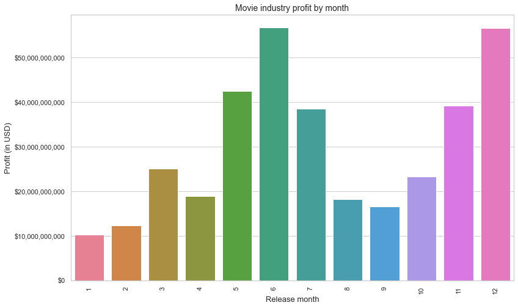

```python
df_profit_by_month = df_movie.groupby('month_released')['profit'].sum().reset_index()

# Set up the Seaborn barplot
sns.set_style("whitegrid")
plt.figure(figsize=(13, 8))
ax = sns.barplot(x='month_released', y='profit', data=df_profit_by_month, palette="husl")

# Set the x-axis label and title
ax.set_xlabel('Release month',fontsize = 13)
ax.set_title('Movie industry profit by month',fontsize = 14)

# Set the y-axis label and format
ax.set_ylabel('Profit (in USD)',fontsize = 13)
ax.yaxis.set_major_formatter('${x:,.0f}')

# Rotate the x-axis tick labels
plt.xticks(rotation=90)

# Show the plot
plt.show()
```

> It seems like the sales focus in the middle of the year and the end of the year. However, the trend for the recents years might have changed as the number of cinemas had risen dramatically and it may change the behaviour of the audience. (For example, in the past they only used their free time of the year to go to the the film theater in big city but now they can easily access it). So i will observe the trend since 1990s.

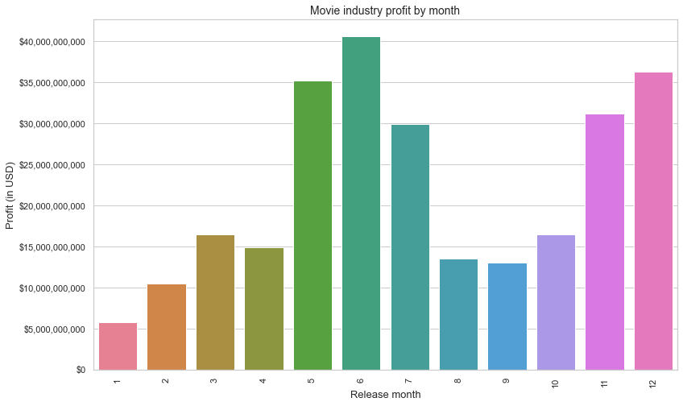

```python
# Filter the dataset by 'released_year' > 1990
df_filtered = df_movie[df_movie['release_year'] > 1990]

# Group the filtered dataset by 'month_released' and sum the 'profit' column
df_profit_by_month = df_filtered.groupby('month_released')['profit'].sum().reset_index()

# Set up the Seaborn barplot
sns.set_style("whitegrid")
plt.figure(figsize=(13, 8))
ax = sns.barplot(x='month_released', y='profit', data=df_profit_by_month, palette="husl")

# Set the x-axis label and title
ax.set_xlabel('Release month',fontsize = 13)
ax.set_title('Movie industry profit by month',fontsize = 14)

# Set the y-axis label and format
ax.set_ylabel('Profit (in USD)',fontsize = 13)
ax.yaxis.set_major_formatter('${x:,.0f}')

# Rotate the x-axis tick labels
plt.xticks(rotation=90)

# Show the plot
plt.show()
```

> It seems like the trend is accurate for all time. So it would be the best to relsease the movie around the middle of the year or near the end of the year having other factors excluded ( competitor movie for example)

## Conclusions

[output not shown]

#### Limitations of the investigations:

- The above analysis rely only visualization of the dataset. Therefore some conclusions maybe bias and further actions shouldn't be conducted from that. This should be support by statistical tests to see the correlations clearly between the variables
- Also since the taste and infrastructure for watching movie had changes dramatically over times, the analysis should be more accurate to assets them by dividing time variable to different group ( for ie. pre 2000s and post2000s) this would also help our visualization to be observe easier